# Highway Impact Simulation

We will analyze the effect of the completion of the Santa Monica Bridge that is currently under construction. This bridge is intended to address traffic congestion by connecting the Ortigas CBD with Bonifacio Global City (BGC).

```python
import psycopg2
import networkx as nx
import osmnx as osx
import pandas as pd
import geopandas as gpd
from shapely.geometry import Point,Polygon,LineString
import matplotlib.pyplot as plt
import folium

import matplotlib.cm as cm
import matplotlib.colors as colors
```

```python
# conn = psycopg2.connect(dbname="aadeleon",
#                  user="aadeleon",
#                  password="",
#                  host="127.0.0.1",
#                  port=5432)
```

# Load our functions

```python
def shortest_distance(graph, o_c, dest_c):
    """
    Creates a GeoDataFrame containing the edges of the shortest path
    from an origin to a destination point. These edges are represented
    as linestrings that can be plotted on a map (folium works)

    Also prints the distance of the computed path.

    Parameters
    ----------
    graph : Graph
        osmnx graph of the area containing the points

    o_c : tuple of floats
        coordinates of origin point in Long/Lat format

    dest_c : tuple of floats
        coordinates of destination point in Long/Lat format

    Returns
    -------
    path_gdf : GeoDataFrame

    shortest_dist : float
    """
    gdf = gpd.GeoDataFrame([{"geometry": Point(o_c)},
                            {"geometry": Point(dest_c)}],
                           crs={'init':'epsg:4326'})
    gdf.to_crs({'init': 'epsg:32651'}, inplace=True)
    origin_point = gdf.loc[0].geometry
    dest_point = gdf.loc[1].geometry

    O = osx.get_nearest_node(graph, (origin_point.y, origin_point.x),
                             method='euclidean', return_dist=True)
    D = osx.get_nearest_node(graph, (dest_point.y, dest_point.x),
                             method='euclidean', return_dist=True)
#     display(gdf)
    path = nx.shortest_path(graph, source=O[0], target=D[0])
    path_edges = []
    adj = graph.adj
    for i in range(0,len(path)-1):
        edges = adj[path[i]][path[i+1]]
        min_length = float("inf")
        min_edge = None
        for key in edges:
            edge = edges[key]
            if edge["length"] < min_length:
                min_length = edge["length"]
                min_edge = edge
        path_edges.append((path[i],path[i+1],min_edge))
    node_dict = dict(graph.nodes)

    gdf_builder = []
    for edge in path_edges:
        u = node_dict[edge[0]]
        v = node_dict[edge[1]]
        curr = edge[2]
        if "geometry" not in curr:
            geom = LineString([(u['x'],u['y']),(v['x'],v['y'])])
        else:
            geom = curr['geometry']
        res = {"source": edge[0], "target": edge[1],
           "distance": edge[2]['length'],"geometry":geom}
        gdf_builder.append(res)
    path_gdf = gpd.GeoDataFrame(gdf_builder,crs={'init':'epsg:32651'})
    path_gdf.to_crs({'init':'epsg:4326'},inplace=True)
    path_gdf

    shortest_dist = path_gdf['distance'].sum()
#     print('distance:', shortest_dist)

    # compute shortest path
#     best_path = nx.shortest_path_length(graph, Point(o_c), Point(dest_c))
    return path_gdf, shortest_dist
```

```python
def map_builder(graph, loc, dest, F_list, n):
    """
    NOTE: keep all inputs in lat/long format.

    Parameters
    ----------
    loc : tuple
        center from where to make the map

    dest : tuple
        destination of all pts

    F_list : list of tuples
        all origin points
    """
    curr_map = folium.Map(location = loc, zoom_start=n)

    folium.Marker(
            location=dest,
            popup='Destination',
            icon=folium.Icon(color='red')
            ).add_to(curr_map)

#     gdfs = []
    dists = []

    for pair in F_list:
        try:
            gdf, dist = shortest_distance(graph, pair[::-1], dest[::-1])
            dists.append(dist)

            geo_json = gdf.to_json()
            path = folium.features.GeoJson(geo_json)
            path.add_to(curr_map)

            folium.Marker(
                location=pair).add_to(curr_map)
#             print('added to map')
        except:
            print('location outside graph')

    return curr_map
```

```python
def compute_time(speed, distance, return_minutes=True):
    """
    Parameters
    ----------
    speed : int
        speed in km/h
    distance : float
        distance in m
    """
    ms_speed = speed/3.6
    seconds = distance/ms_speed
    mins = seconds/60
    hours = mins/60
    if return_minutes:
        return round(mins, 2)
    else:
        return round(hours, 2)
```

# Load and Plot Graph

You can specify what types of streets to extract by passing a string to `network_type`. These options include the following:

- `drive` – get drivable public streets (but not service roads)
- `drive_service` – get drivable public streets, including service roads
- `walk` – get all streets and paths that pedestrians can use (this network type ignores one-way directionality)
- `bike` – get all streets and paths that cyclists can use
- `all` – download all (non-private) OSM streets and paths
- `all_private` – download all OSM streets and paths, including private-access ones

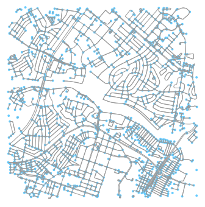

```python
center = 14.565958, 121.054762

graph_before = osx.graph_from_point(center, distance=1500,
                             network_type='drive_service',
                             retain_all=True)
plot = osx.plot_graph(graph_before)
```

```python
graph_before = osx.project_graph(graph_before, to_crs={'init': 'epsg:32651'})
```

# Drawing the Original Path

For example, I want to go from Capitol Commons in Ortigas to UpTown Mall in BGC. We can draw this path using the `shortest_distance` function.

```python
cap_commons = 14.575811, 121.063515
uptown = 14.567278, 121.051384

way1, dist1 = shortest_distance(graph_before, cap_commons[::-1], uptown[::-1])
```

```python
maps = map_builder(graph_before, center, uptown, [cap_commons], 14)
maps
```

[interactive chart not shown]

```python
print("Distance in meters:", dist1)
```

```
Distance in meters: 4597.197
```

# Identify Nodes Santa Monica Bridge Connects

If we want to simulate the creation of a new bridge or road, we need to make computations on a separate graph object. We load `graph_after` as the road network we'll be creating the bridge in.

```python
p1 = 14.566374, 121.054880
p2 = 14.564870, 121.054464

center = 14.565958, 121.054762

graph_after = osx.graph_from_point(center, distance=1500,
                             network_type='drive_service',
                             retain_all=True)

# graph = osx.project_graph(graph, to_crs={'init': 'epsg:32651'})
```

Checking the nodes and edges of a graph is standard practice, although I do this just to inspect the features of the `edges` table. This will give us an idea on what the features our new edge (or bridge in this case) will have when we generate it.

```python
nodes, edges = osx.graph_to_gdfs(graph_after, nodes=True, edges=True)
```

Here, we need to get the nodes closest to the starting and end points of Santa Monica bridge. `O` and `D` will serve as starting points. `add_edge` does exactly what its name says. We set a `key` value to it just so we can check later on if the edge was indeed created with the intended features.

```python
O = osx.get_nearest_node(graph_after, (p1),
                         method='euclidean')
D = osx.get_nearest_node(graph_after, (p2),
                         method='euclidean')

graph_after.add_edge(O, D, key=113, highway='trunk', length=613.77,
                                           oneway=False,
                                         lanes=4)
```

```
113
```

```python
# edges
```

```python
nodes, edges = osx.graph_to_gdfs(graph_after, nodes=True, edges=True)
```

```python
edges[edges['key']==113]
```

|  | u | v | key | osmid | name | highway | oneway | length | geometry | lanes | ref | maxspeed | access | bridge | service | junction | tunnel |
| --- | --- | --- | --- | --- | --- | --- | --- | --- | --- | --- | --- | --- | --- | --- | --- | --- | --- |
| 220 | 88908197 | 242434215 | 113 | NaN | NaN | trunk | False | 613.77 | LINESTRING (121.05524 14.56700, 121.05445 14.5... | 4 | NaN | NaN | NaN | NaN | NaN | NaN | NaN |

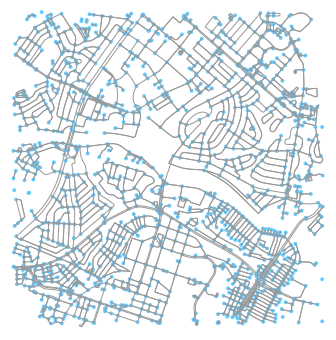

[output not shown]

```python
osx.plot_graph(graph_after)
```

You'll notice a new line has appeared at the graph's center, which is the edge we created just now.

```python
graph_after = osx.project_graph(graph_after, to_crs={'init': 'epsg:32651'})
map_builder(graph_after, center, uptown, [cap_commons], 14)
```

[interactive chart not shown]

```python
way2, dist2 = shortest_distance(graph_after, cap_commons[::-1], uptown[::-1])
dist2
```

```
2807.165
```

```python
way2
```

|  | source | target | distance | geometry |
| --- | --- | --- | --- | --- |
| 0 | 6630554096 | 3570781002 | 10.077 | LINESTRING (121.06352 14.57609, 121.06344 14.5... |
| 1 | 3570781002 | 4279836845 | 102.303 | LINESTRING (121.06344 14.57613, 121.06334 14.5... |
| 2 | 4279836845 | 5454100037 | 12.566 | LINESTRING (121.06308 14.57529, 121.06306 14.5... |
| 3 | 5454100037 | 3137151629 | 124.972 | LINESTRING (121.06297 14.57527, 121.06291 14.5... |
| 4 | 3137151629 | 3137151630 | 12.049 | LINESTRING (121.06211 14.57601, 121.06202 14.5... |
| 5 | 3137151630 | 746028183 | 86.801 | LINESTRING (121.06202 14.57608, 121.06150 14.5... |
| 6 | 746028183 | 88795625 | 73.169 | LINESTRING (121.06150 14.57548, 121.06112 14.5... |
| 7 | 88795625 | 3762081957 | 12.394 | LINESTRING (121.06106 14.57498, 121.06098 14.5... |
| 8 | 3762081957 | 3762081958 | 13.829 | LINESTRING (121.06098 14.57490, 121.06108 14.5... |
| 9 | 3762081958 | 332538700 | 115.530 | LINESTRING (121.06108 14.57482, 121.06139 14.5... |
| 10 | 332538700 | 92297854 | 65.535 | LINESTRING (121.06185 14.57409, 121.06169 14.5... |
| 11 | 92297854 | 88905462 | 166.591 | LINESTRING (121.06143 14.57366, 121.06137 14.5... |
| 12 | 88905462 | 1941045525 | 225.838 | LINESTRING (121.06024 14.57272, 121.06012 14.5... |
| 13 | 1941045525 | 1941045512 | 351.572 | LINESTRING (121.05836 14.57180, 121.05731 14.5... |
| 14 | 1941045512 | 88903444 | 131.556 | LINESTRING (121.05587 14.56989, 121.05579 14.5... |
| 15 | 88903444 | 88905454 | 80.501 | LINESTRING (121.05576 14.56873, 121.05585 14.5... |
| 16 | 88905454 | 88908197 | 152.731 | LINESTRING (121.05611 14.56809, 121.05524 14.5... |
| 17 | 88908197 | 242434215 | 613.770 | LINESTRING (121.05524 14.56700, 121.05445 14.5... |
| 18 | 242434215 | 313514846 | 19.150 | LINESTRING (121.05445 14.56473, 121.05432 14.5... |
| 19 | 313514846 | 5870059699 | 48.032 | LINESTRING (121.05432 14.56484, 121.05430 14.5... |
| 20 | 5870059699 | 5877110205 | 111.237 | LINESTRING (121.05405 14.56519, 121.05357 14.5... |
| 21 | 5877110205 | 4333533671 | 147.303 | LINESTRING (121.05339 14.56596, 121.05277 14.5... |
| 22 | 4333533671 | 6660723427 | 129.659 | LINESTRING (121.05236 14.56683, 121.05223 14.5... |

```python
dist1, dist2
```

```
(4597.197, 2807.165)
```

# Building the comparison Visualization

```python
curr_map = folium.Map(location = center, zoom_start = 14)

# folium.FeatureGroup(name="before").add_to(curr_map)
# folium.FeatureGroup(name='after').add_to(curr_map)

geojson = way1.to_json()
path1 = folium.features.GeoJson(geojson, name='before', style_function=lambda x: {'color':'green'})
path1.add_to(curr_map)

geojson = way2.to_json()
path2 = folium.features.GeoJson(geojson, name='after')
path2.add_to(curr_map)

folium.Marker(
        location=uptown,
        popup='Destination',
        icon=folium.Icon(color='red')
        ).add_to(curr_map)

folium.Marker(
        location=cap_commons,
        popup='Origin').add_to(curr_map)

folium.LayerControl().add_to(curr_map)

# folium.PolyLine()

curr_map
```

[interactive chart not shown]

```python
t1 = compute_time(20,dist1)
t2 = compute_time(20,dist2)

distance = [dist1, dist2]
t_time = [t1, t2]
state = ['before', 'after']
```

```python
pd.DataFrame({'state': state, 'time (mins)': t_time, 'distance (m)': distance})
```

|  | state | time (mins) | distance (m) |
| --- | --- | --- | --- |
| 0 | before | 13.79 | 4597.197 |
| 1 | after | 8.42 | 2807.165 |

# Comparing Centrality

```python
# creates a dictionary of nodes and their associated centralities
node_centrality_a = nx.closeness_centrality(graph_before)
```

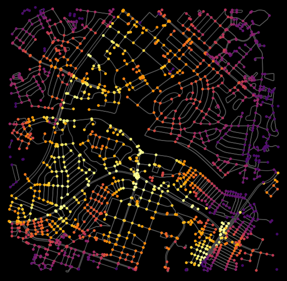

```python
# turn it into a dataframe
df = pd.DataFrame(data=pd.Series(node_centrality_a).sort_values(), columns=['cc'])

df['colors'] = osx.get_colors(n=len(df), cmap='inferno', start=0.2)
df = df.reindex(graph_before.nodes())
nc = df['colors'].tolist()
fig, ax = osx.plot_graph(graph_before, bgcolor='k', node_size=30, node_color=nc, node_edgecolor='none', node_zorder=2,
                        edge_color='#555555', edge_linewidth=1.5, edge_alpha=1, fig_height=10)
```

```python
# edge closeness centrality: convert graph to a line graph so edges become nodes and vice versa
edge_centrality_a = nx.closeness_centrality(nx.line_graph(graph_before))
```

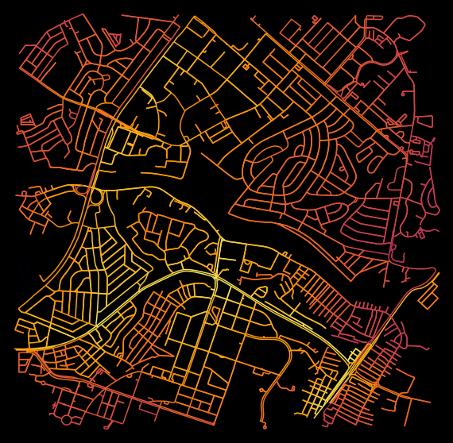

```python
# list of edge values for the orginal graph
ev = [edge_centrality_a[edge + (0,)] for edge in graph_before.edges()]

# color scale converted to list of colors for graph edges
norm = colors.Normalize(vmin=min(ev)*0.8, vmax=max(ev))
cmap = cm.ScalarMappable(norm=norm, cmap=cm.inferno)
ec = [cmap.to_rgba(cl) for cl in ev]

# color the edges in the original graph with closeness centralities in the line graph
fig, (ax1) = osx.plot_graph(graph_before, bgcolor='k', axis_off=True, node_size=0, node_color='w',
                         node_edgecolor='gray', node_zorder=2,
                        edge_color=ec, edge_linewidth=1.5, edge_alpha=1, fig_height=10)
```

# After Node Centrality

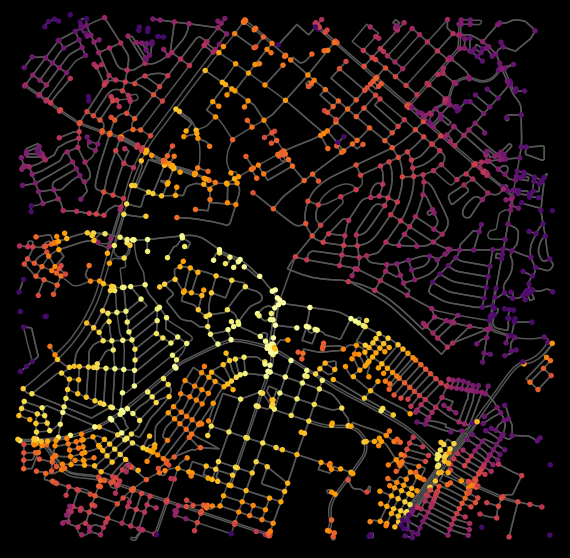

```python
# creates a dictionary of nodes and their associated centralities
node_centrality_b = nx.closeness_centrality(graph_after)

# turn it into a dataframe
df = pd.DataFrame(data=pd.Series(node_centrality_b).sort_values(), columns=['cc'])

df['colors'] = osx.get_colors(n=len(df), cmap='inferno', start=0.2)
df = df.reindex(graph_after.nodes())
nc = df['colors'].tolist()
fig, ax = osx.plot_graph(graph_after, bgcolor='k', node_size=30, node_color=nc, node_edgecolor='none', node_zorder=2,
                        edge_color='#555555', edge_linewidth=1.5, edge_alpha=1, fig_height=10)
```

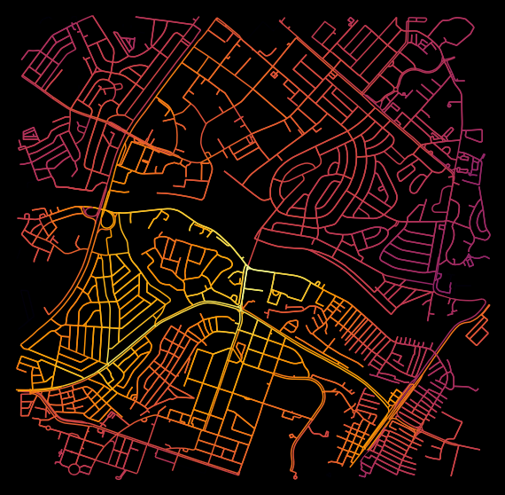

```python
edge_centrality_b = nx.closeness_centrality(nx.line_graph(graph_after))

# list of edge values for the orginal graph
ev = [edge_centrality_b[edge + (0,)] for edge in graph_after.edges()]

# color scale converted to list of colors for graph edges
norm = colors.Normalize(vmin=min(ev)*0.8, vmax=max(ev))
cmap = cm.ScalarMappable(norm=norm, cmap=cm.inferno)
ec = [cmap.to_rgba(cl) for cl in ev]

# color the edges in the original graph with closeness centralities in the line graph
fig, ax = osx.plot_graph(graph_after, bgcolor='k', axis_off=True, node_size=0, node_color='w',
                         node_edgecolor='gray', node_zorder=2,
                        edge_color=ec, edge_linewidth=1.5, edge_alpha=1, fig_height=10)
```

# References

- Centrality measure visualization was sourced from Geoff Boeing's tutorials on his website: https://geoffboeing.com/
- Distance computation references were derived from Hadrian Ang's code, a former colleague.